# Problem Set 10: Regex, grep, and awk

# Instructions

Create a Quarto markdown document and answer the questions below using code blocks that generate the correct outputs. We encourage you to include explanatory text in your markdown document, however **each of your solutions should show how to generate the answer using R code**.

Write “robust” solutions wherever possible. A good rule of thumb for judging whether your solution is appropriately “robust” is to ask yourself “If I added additional observations or variables to this data set, or if the order of variables changed, would my code still compute the right solution?”

Make sure your markdown is nicely formatted – use headers, bullets, numbering, etc so that the structure of the document is clear.

Make sure to “Render” your document before submission to confirm that all code blocks and formatting is as you expect.

When completed, title your markdown file as follows (replace `XX` with the assignment number, e.g. `01`, `02`, etc):

- `netid-assignment_XX-Fall2023.qmd`

Submit both your markdown file and the generated HTML document via the Assignments submission section on Sakai.

# Problems

## Background

[Ste12](https://www.yeastgenome.org/locus/S000001126) is a transcription factor that regulates genes in the pheromone induced mating pathway of the budding yeast *Saccharomyces cerevisiae*.

Studies show that Ste12 recognizes and binds DNA sequence motifs upstream of the genes it regulates. A [sequence logo](http://users.fred.net/tds/lab/how.to.read.sequence.logos/) for the Ste12 binding site is shown in the figure below.

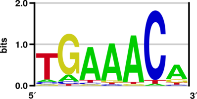

STE12 binding site motif from [The Yeast Transcription Factor Specificity Compendium](http://yetfasco.ccbr.utoronto.ca/)

The canonical sequence motif for Ste12 binding is “TGAAACA” but the sequence logo indicates that some positions can be variable.

For the sake of this problem let’s assume the following:

- The first position can be T or A
- The second postion can be either G or A
- The last position can be either A or G or T
- The intermediate sites need to be “AAAC”

The file STE12_promoter_table.tsv contains information about some genes that Ste12 is hypothesized to regulate. This file has three columns that contain:

1. The systematic ID of each gene
2. A column indicating where in the yeast genome the upstream sequence of each gene (see next field) was copied from
3. A string giving the nucleotide sequence of the 500bp upstream of each gene (case should be ignored)

## Problems

1. Show how to use `grep` to calculate the number of times the Ste12 DNA binding motif appears in the upstream region of the first gene (YAR009C) in the table. Account for variable positions in your count.
2. **Medium:** Write an Awk script, `countmotif.awk` that calculates the number of candidate Ste12 DNA binding motifs found in the upstream region of each gene in `STE12_promoter_table.tsv`. Account for variable positions in your count. Your script should return a tab delimited table of the form:

   ```
   systematic_name motif_count
   YAR009C          2
   YBR067C          0
   YCL027W          3
   YDR365W-B        1
   ...<output truncated>...
   ```

3. **Advanced:** Write an Awk script, `motifmatches.awk`, that returns both the motif count and the found matches. Your output should return a tab-delimited table of the form:

   ```
   systematic_name motif_count matches
   YAR009C 2   AGAAACT,aaaaacg,
   YBR067C 0
   YCL027W 3   TGAAACA,TGAAACG,tgaaaca,
   YDR365W-B   1   tgaaacg,
   ```